# Homework 4 Solutions

Amy Allen & Dayne Filer

July 5, 2016

1. Create a new fruit list with 5000 fruit instead of 25, count the number of apples and the number of oranges.

Make the new fruit list.

```r
fruit <- list(type = sample(x = c("orange", "apple"),
                            size = 5000,
                            replace = TRUE),
              wdth = rnorm(n = 5000, mean = 6, sd = 2.5))
```

There are multiple ways to find the number of apples and oranges. Here are two options. The first option uses the `length` function of the object `type` from the list `fruit` subsetted for those entries where `type` is apples or oranges. The second option uses the `sum` function to take a sum of a logical vector. This works because the logical vector is coerced to zeros and ones, making the sum equivalent to the number of true statements.

```r
n_apple <- length(fruit$type[fruit$type=="apple"]) #numer of apples
n_orange <- length(fruit$type[fruit$type=="orange"]) # number of oranges
n_apple
```

```
## [1] 2507
```

```r
n_orange
```

```
## [1] 2493
```

```r
n_apple <- sum(fruit$type=="apple") #numer of apples
n_orange <- sum(fruit$type=="orange") # number of oranges
n_apple
```

```
## [1] 2507
```

```r
n_orange
```

```
## [1] 2493
```

2. Modify the fruit machine program to throw out the slices that are less than 0.7 inches and track the number of fruit discarded.

```r
## Create result list
res <- list(type = character(), pieces = numeric(), slice_width = numeric())

## Create a count of disgarded fruit
disgarded <- 0

## For-loop iterating through the 1:(number of fruit)
for (f in 1:length(fruit$type)) {
  f_type <- fruit$type[f] ## Get the fruit type from the list
  f_wdth <- fruit$wdth[f] ## Get the fruit width from the list
  n_pieces <- 1 ## Each fruit is initially 1 piece

  ## Peel the oranges
  if (f_type == "orange") {
    f_wdth <- f_wdth - 1/8
  }

  ## Divide the fruit
  while (f_wdth >= 1) {
    f_wdth <- f_wdth/2
    n_pieces <- n_pieces*2
  }

  ## Disgard if slice width is less that 0.7
  if (f_wdth < 0.7){
    res$type[f] <- "disgarded"
    res$pieces[f] <- NA
    res$slice_width[f] <- NA
    disgarded <- disgarded + 1
  }
  else{
    res$type[f] <- f_type
    res$pieces[f] <- n_pieces
    res$slice_width[f] <- f_wdth
  }

}

## print disgarded
disgarded
```

```
## [1] 2429
```

3. Further modify the fruit machine program to make orange slices between 0.7 and 1.0 inches and apple slices between 0.3 and 0.5 inches. Track how many oranges are discarded and how many apples are discarded.

```r
## Create result list
res <- list(type = character(), pieces = numeric(), slice_width = numeric())

## Create a count of disgarded fruits
disgarded_orange <- 0
disgarded_apple <- 0

## For-loop iterating through the 1:(number of fruit)
for (f in 1:length(fruit$type)) {
  f_type <- fruit$type[f] ## Get the fruit type from the list
  f_wdth <- fruit$wdth[f] ## Get the fruit width from the list
  n_pieces <- 1 ## Each fruit is initially 1 piece

  ## Peel the oranges
  if (f_type == "orange") {
    f_wdth <- f_wdth - 1/8
  }

  ## Divide oranges and discard if slices are smaller than 0.7
  if (f_type == "orange"){
    while (f_wdth >= 1) {
      f_wdth <- f_wdth/2
      n_pieces <- n_pieces*2
    }
    if (f_wdth < 0.7){
      res$type[f] <- "disgarded"
      res$pieces[f] <- NA
      res$slice_width[f] <- NA
      disgarded_orange <- disgarded_orange + 1
    }
    else{
      res$type[f] <- f_type
      res$pieces[f] <- n_pieces
      res$slice_width[f] <- f_wdth
    }
  }
  ## Divide apples and discard if pieces are less than 0.3
  if (f_type == "apple"){
    while (f_wdth >= 0.5) {
      f_wdth <- f_wdth/2
      n_pieces <- n_pieces*2
    }
    if (f_wdth < 0.3){
      res$type[f] <- "disgarded"
      res$pieces[f] <- NA
      res$slice_width[f] <- NA
      disgarded_apple <- disgarded_apple + 1
    }
    else{
      res$type[f] <- f_type
      res$pieces[f] <- n_pieces
      res$slice_width[f] <- f_wdth
    }
  }
}

## print disgarded
disgarded_apple
```

```
## [1] 700
```

```r
disgarded_orange
```

```
## [1] 1211
```

4. Plot a histogram of the apple slice widths.

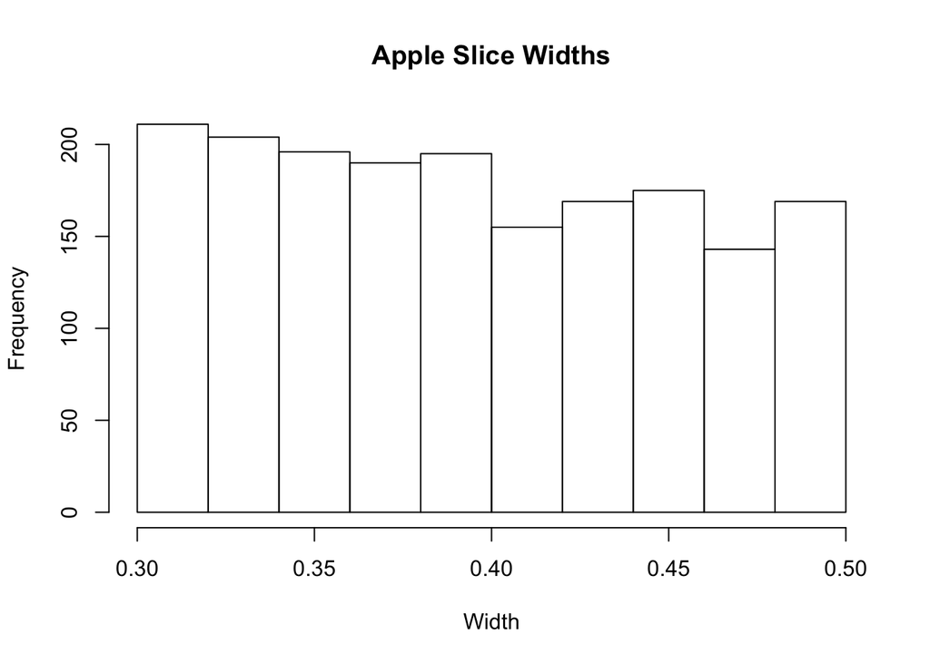

```r
hist(res$slice_width[res$type=="apple"],
     main = "Apple Slice Widths",
     xlab = "Width")
```

5. Plot a histogram of the number of orange slices.

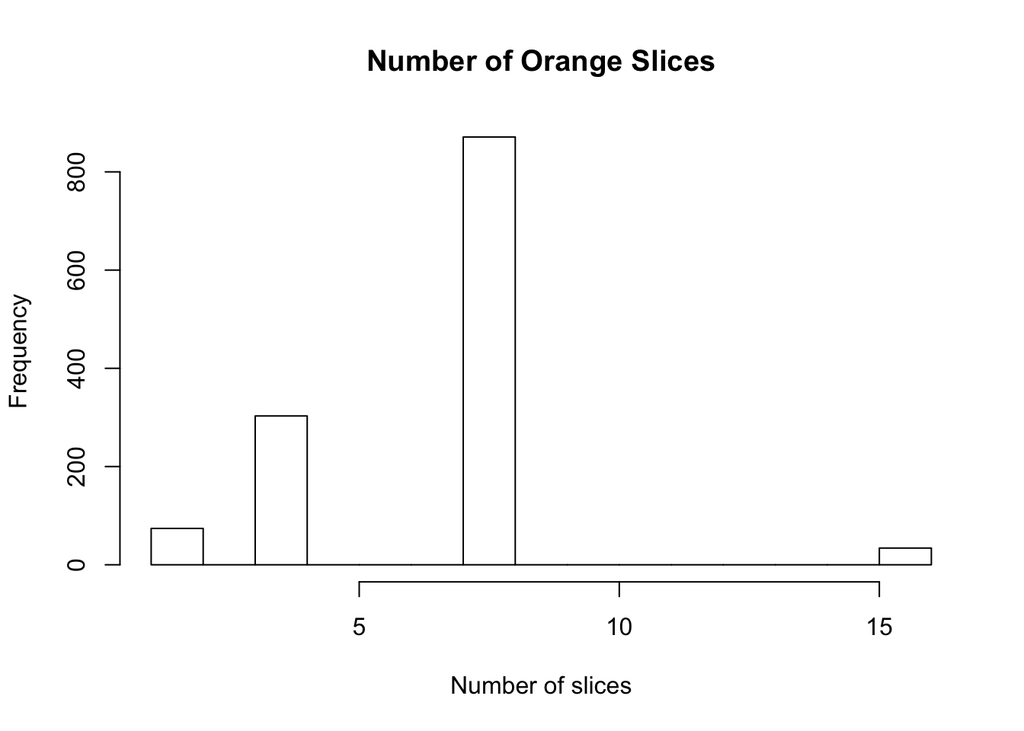

```r
hist(res$pieces[res$type=="orange"],
     main = "Number of Orange Slices",
     xlab = "Number of slices")
```